# Aging in the Northern Border Region

An example slide deck for CDAE 7990

Andrew Van Leuven

November 19, 2026

## The Bottom Line

- **Older:** 21.2% of the region’s residents are 65 or older, compared with 17.2% nationally
- **Everywhere:** 61 of the 63 NBRC counties are older than the U.S. as a whole
- **Least care where need is greatest:** the oldest counties have the fewest nursing home beds per senior, and 5 counties have no certified nursing home at all

## The Region Is Older Than the Country

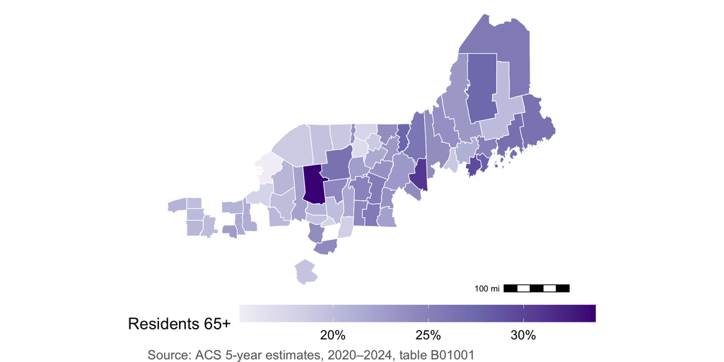

## The Oldest Counties Keep Getting Older

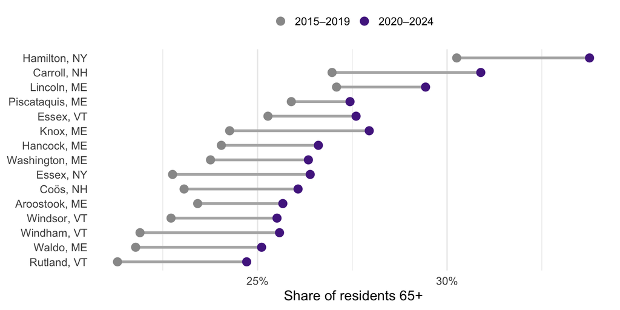

## Five Counties Have No Certified Nursing Home

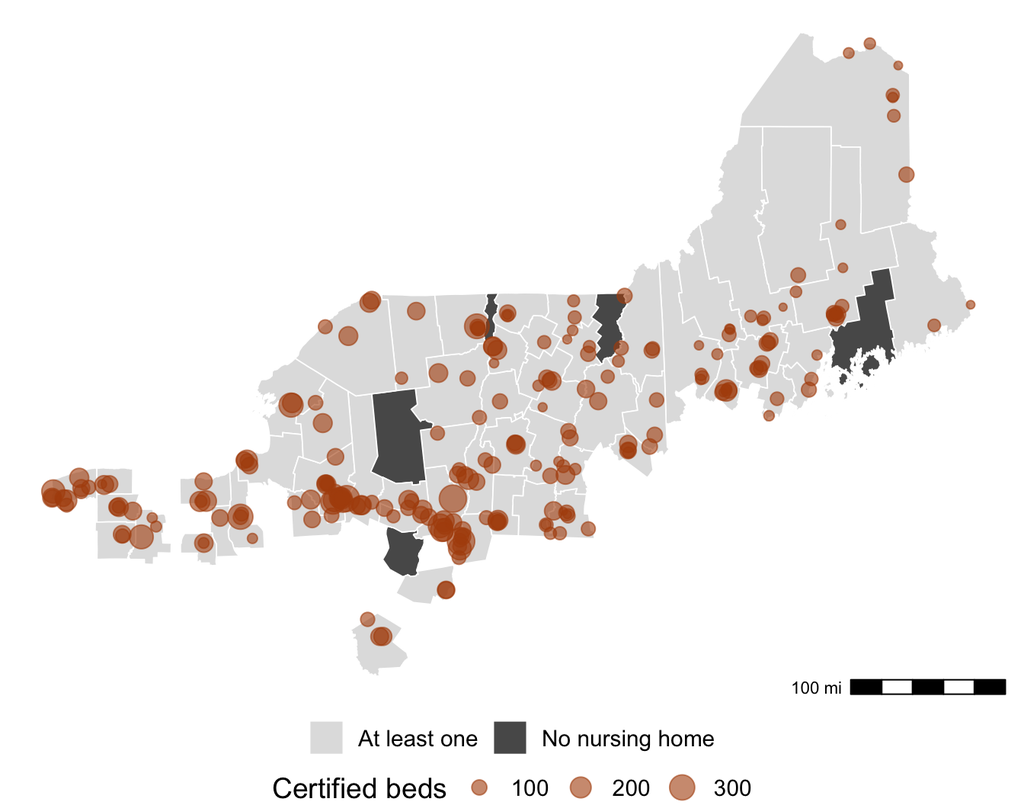

**No certified nursing home** (residents 65+):

- Hancock, ME (15,021)
- Schoharie, NY (7,181)
- Grand Isle, VT (1,755)
- Hamilton, NY (1,718)
- Essex, VT (1,651)

## Older Counties Have Fewer Beds per Senior

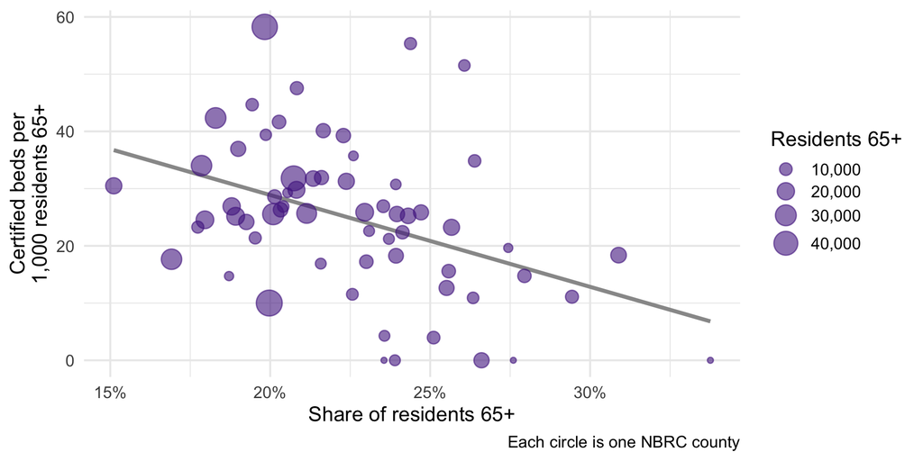

## More Than a Quarter of the Region’s Nursing Homes Have One Star

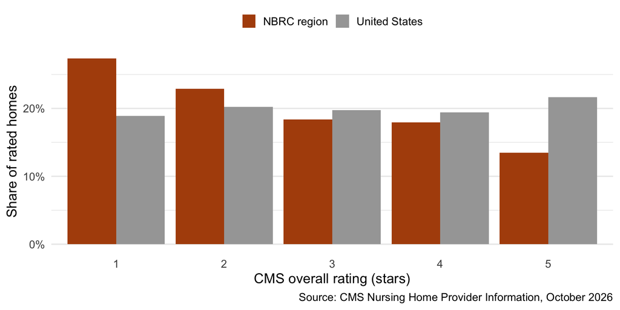

## What This Means for NBRC

- The oldest counties have the least nursing home capacity per senior, which makes them the natural place to look first when weighing elder care investment
- Nursing homes are also employers, and their staffing is part of the region’s workforce story
- **Next step:** add assisted living and home health, which these counts leave out

## About the Data

- **Population:** American Community Survey 5-year estimates (2015–2019 and 2020–2024), table B01001, pulled with `tidycensus`. Regional shares add up county counts first, then divide.
- **Nursing homes:** CMS Nursing Home Provider Information, October 2026. Medicare- and Medicaid-certified homes only, placed in counties with a spatial join on their coordinates.
- **Region:** the 63 NBRC counties in Maine, New Hampshire, New York, and Vermont
- **Caveats:** ACS figures carry margins of error, widest for the smallest counties. Beds per senior ignores people crossing county lines for care.